# Resultados de Elecciones Internas 2024

Realizado por Emiliano Clavijo (Universidad de la República, Uruguay)

2024-09-04

## Trabajo con geocodificación aplicada a resultados electorales

Se procede a cargar la base de series con la asistencia de la librería “sf”. Trabajamos con shapefile, porque la descarga de .csv presenta complejidades en el trazado del mapa. Los archivos pueden descargarse a partir del acceso al visualizador catrográfico de IDE que contiene capas diseñadas en acuerdo con la Corte Electoral: https://www.gub.uy/corte-electoral/datos-y-estadisticas/datos/visualizador-cartografia-digital

```r
library(sf)
shapefile_path <- "geogr/series_electorales_20240523.shp"
uruguay_shp <- st_read(shapefile_path)
```

Se traza el mapa a utilizar para su verificación de que las salidas serán consistentes en su trazado.

```r
head(uruguay_shp)
```

```
Simple feature collection with 6 features and 3 fields
Geometry type: MULTIPOLYGON
Dimension:     XY
Bounding box:  xmin: -54.18593 ymin: -32.54564 xmax: -54.02444 ymax: -32.24734
Geodetic CRS:  WGS 84
  ogc_fid serie       depto                       geometry
1       1   GAA CERRO LARGO MULTIPOLYGON (((-54.16462 -...
2       2   GAB CERRO LARGO MULTIPOLYGON (((-54.16996 -...
3       3   GAC CERRO LARGO MULTIPOLYGON (((-54.16889 -...
4       4   GAD CERRO LARGO MULTIPOLYGON (((-54.16466 -...
5       5   GBA CERRO LARGO MULTIPOLYGON (((-54.15443 -...
6       6   GBB CERRO LARGO MULTIPOLYGON (((-54.05728 -...
```

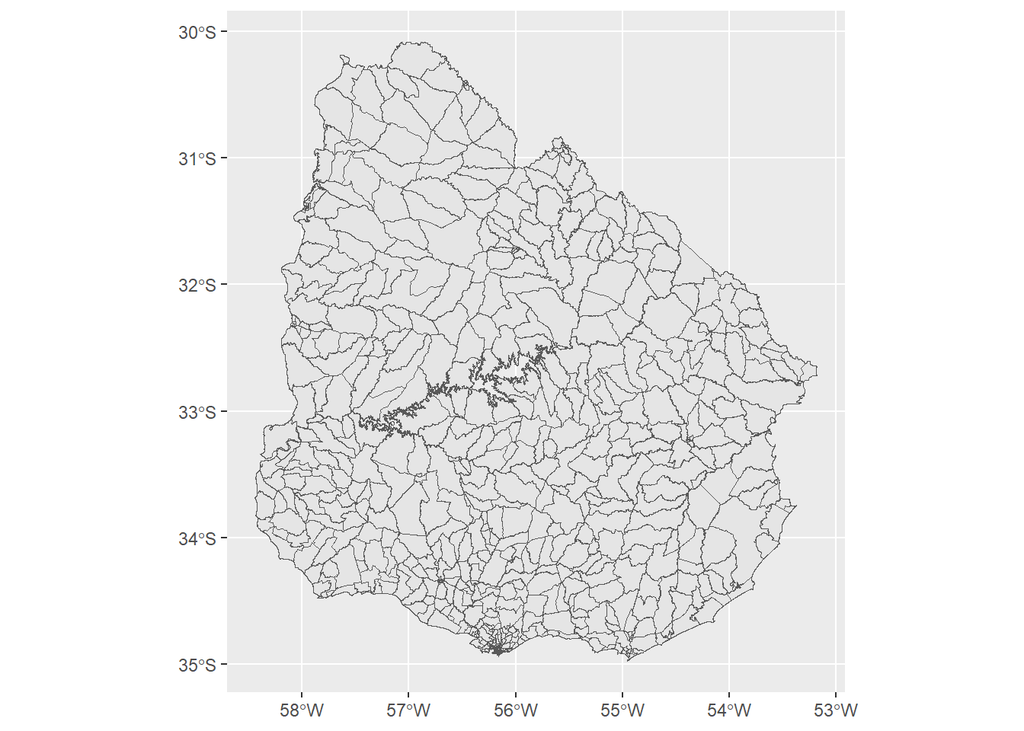

```r
ggplot(uruguay_shp)+
  geom_sf()
```

Luego, vamos a cargar los votos de las EI2024 Fuente: Corte Electoral

```r
# Votos

download.file("https://catalogodatos.gub.uy/dataset/48a4e7f5-6909-41a0-aa8a-95dc42cc201f/resource/dec32eb5-1754-4810-af7a-8c1121259206/download/desglose-de-votos.csv", destfile = "desglose_de_votos.csv")

# Leer el archivo CSV con los votos
desglose_votos <- read.csv("desglose_de_votos.csv")
```

Llamamos en los df de interés a Serie de la misma forma. Esto va a permitir mergear ubicación con series y votos.

```r
# Renombrar la columna en uruguay_shp si es necesario
colnames(uruguay_shp)[colnames(uruguay_shp) == "serie"] <- "Serie"

# Renombrar la columna en desglose_votos si es necesario
colnames(desglose_votos)[colnames(desglose_votos) == "SERIES"] <- "Serie"
```

Ahora, mergeamos.

```r
# Luego unir el resultado con desglose_votos
internas2024 <- merge(uruguay_shp, desglose_votos, by = "Serie")
```

Vemos estructura de la base mergeada.

```r
head(internas2024)
```

```
Simple feature collection with 6 features and 10 fields
Geometry type: MULTIPOLYGON
Dimension:     XY
Bounding box:  xmin: -56.223 ymin: -34.91053 xmax: -56.19645 ymax: -34.896
Geodetic CRS:  WGS 84
  Serie ogc_fid      depto TIPO_REGISTRO DEPARTAMENTO CRV             LEMA
1   AAA     374 MONTEVIDEO      HOJA_ODN           MO   7    FRENTE AMPLIO
2   AAA     374 MONTEVIDEO      HOJA_ODN           MO   7 PARTIDO COLORADO
3   AAA     374 MONTEVIDEO      HOJA_ODN           MO   7    FRENTE AMPLIO
4   AAA     374 MONTEVIDEO      HOJA_ODD           MO   2 PARTIDO NACIONAL
5   AAA     374 MONTEVIDEO      HOJA_ODN           MO   2 PARTIDO NACIONAL
6   AAA     374 MONTEVIDEO      HOJA_ODD           MO   8 PARTIDO NACIONAL
                   DESCRIPCIÓN_1 DESCRIPCIÓN_2 CANTIDAD_VOTOS
1   ORSI MARTINEZ, Yamandu Ramon          1968              1
2 GURMENDEZ ARMAND UGON, Gabriel           220              1
3   ORSI MARTINEZ, Yamandu Ramon          3098              1
4                      No aplica        404404              5
5  RAFFO DEGEROMINI, Maria Laura          2004              3
6                      No aplica             4              2
                        geometry
1 MULTIPOLYGON (((-56.19856 -...
2 MULTIPOLYGON (((-56.19856 -...
3 MULTIPOLYGON (((-56.19856 -...
4 MULTIPOLYGON (((-56.19856 -...
5 MULTIPOLYGON (((-56.19856 -...
6 MULTIPOLYGON (((-56.19856 -...
```

## Ejemplo: distribución de votos de Cabildo Abierto al ODN por serie

Se inicia el ejercicio con el filtrado de los votos por serie electoral al ODN de Cabildo Abierto.

```r
# Filtramos los datos para lema "CABILDO ABIERTO" y votos al Organo Deliberativo Nacional "HOJA_ODN"
cabildo_abierto_odn <- internas2024 %>%
  filter(LEMA == "CABILDO ABIERTO" & TIPO_REGISTRO == "HOJA_ODN")
```

Ahora, hay que agrupar los votos por serie y sumarlos:

```r
# Agrupamos por Serie y Departamento y sumar los votos
votos_por_serie_cabildo <- cabildo_abierto_odn %>%
  group_by(Serie, DEPARTAMENTO) %>%
  summarise(votos_totales = sum(CANTIDAD_VOTOS, na.rm = TRUE))

# Resultado
head(votos_por_serie_cabildo)
```

```
Simple feature collection with 6 features and 3 fields
Geometry type: POLYGON
Dimension:     XY
Bounding box:  xmin: -56.223 ymin: -34.91609 xmax: -56.17678 ymax: -34.896
Geodetic CRS:  WGS 84
# A tibble: 6 × 4
# Groups:   Serie [6]
  Serie DEPARTAMENTO votos_totales                                      geometry
  <chr> <chr>                <int>                                 <POLYGON [°]>
1 AAA   MO                      39 ((-56.19887 -34.89653, -56.19921 -34.89644, …
2 ACA   MO                      23 ((-56.19737 -34.90637, -56.19808 -34.90642, …
3 AIA   MO                      53 ((-56.18607 -34.90053, -56.18643 -34.89968, …
4 AKA   MO                      78 ((-56.18517 -34.90549, -56.18541 -34.90553, …
5 AMA   MO                      29 ((-56.1859 -34.90111, -56.18592 -34.90113, -…
6 APA   MO                      35 ((-56.17723 -34.91433, -56.17728 -34.91425, …
```

Veamos las diez series con más votos obtenidos por el Lema Cabildo Abierto.

```r
# Ordeno por votos_totales en orden descendente y se muestran los 10 valores máximos
top_10_votos_CA_INT_2024 <- votos_por_serie_cabildo %>%
  arrange(desc(votos_totales)) %>%
  head(10)

# Resultado
print(top_10_votos_CA_INT_2024)
```

```
Simple feature collection with 10 features and 3 fields
Geometry type: POLYGON
Dimension:     XY
Bounding box:  xmin: -58.39265 ymin: -34.92212 xmax: -53.28982 ymax: -30.38484
Geodetic CRS:  WGS 84
# A tibble: 10 × 4
# Groups:   Serie [10]
   Serie DEPARTAMENTO votos_totales                                     geometry
   <chr> <chr>                <int>                                <POLYGON [°]>
 1 IAC   AR                     872 ((-56.45559 -30.39822, -56.4556 -30.39819, …
 2 GDA   CL                     441 ((-53.45616 -32.52642, -53.45654 -32.52629,…
 3 HAB   RV                     424 ((-55.55023 -30.88529, -55.55065 -30.88516,…
 4 BOB   MO                     274 ((-56.13753 -34.77592, -56.13749 -34.77571,…
 5 MAA   SO                     260 ((-58.01882 -33.24312, -58.01883 -33.24312,…
 6 LAA   RN                     237 ((-58.1014 -33.06414, -58.10137 -33.06411, …
 7 BDA   MO                     233 ((-56.15555 -34.84654, -56.15546 -34.84659,…
 8 BOA   MO                     232 ((-56.14689 -34.73013, -56.14689 -34.73006,…
 9 DAA   MA                     224 ((-54.95293 -34.88678, -54.95334 -34.8869, …
10 JCD   SA                     223 ((-57.98445 -31.35607, -57.98453 -31.35616,…
```

Grafiquemos un mapa coroplético. Varias opciones:

1. Mapeo estándar con coloreo de transición lineal

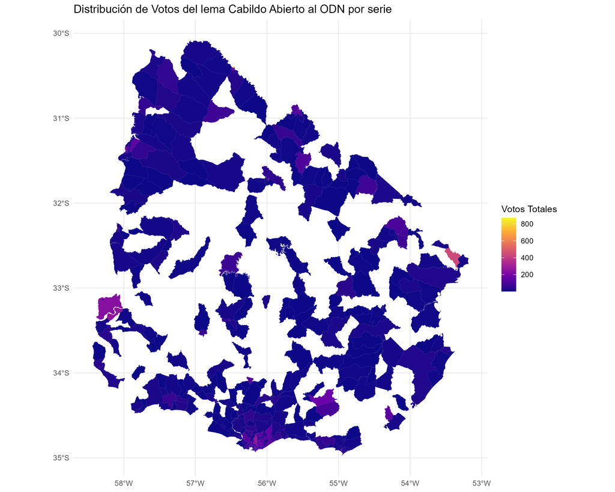

```r
mapa_coropletico <- ggplot(votos_por_serie_cabildo) +
  geom_sf(aes(fill = votos_totales), color = NA) +
  scale_fill_viridis_c(option = "plasma", na.value = "white",
                       breaks = scales::pretty_breaks(n = 5)) +  # Genera cortes lineales
  theme_minimal() +
  labs(title = "Distribución de Votos del lema Cabildo Abierto al ODN por serie",
       fill = "Votos Totales")

# Guardar el mapa como archivo PNG
ggsave("mapa_coropletico.png", plot = mapa_coropletico, width = 10, height = 8, dpi = 300)
```

2. Colores con transición logaritmica

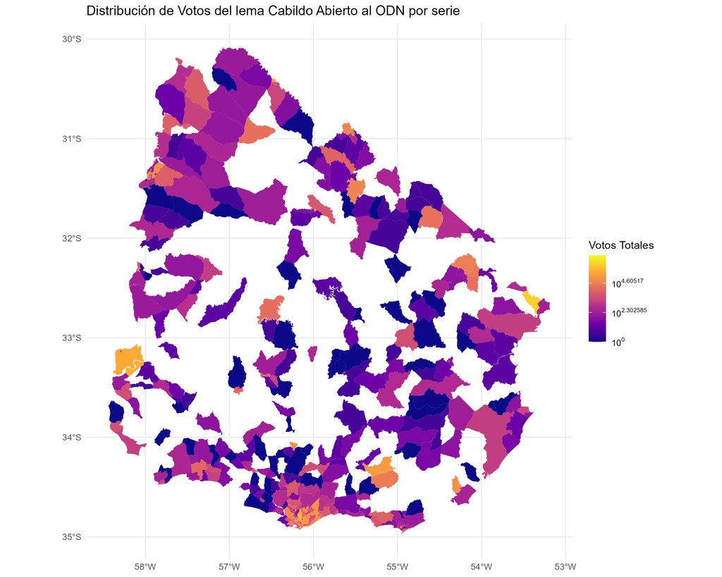

```r
mapa_coropletico_2 <- ggplot(votos_por_serie_cabildo) +
  geom_sf(aes(fill = votos_totales), color = NA) +
  scale_fill_viridis_c(option = "plasma", na.value = "white",
                       trans = "log",
                       breaks = scales::trans_breaks("log", function(x) 10^x),
                       labels = scales::trans_format("log", scales::math_format(10^.x))) +
  theme_minimal() +
  labs(title = "Distribución de Votos del lema Cabildo Abierto al ODN por serie",
       fill = "Votos Totales")
ggsave("mapa_coropletico_2.png", plot = mapa_coropletico_2, width = 10, height = 8, dpi = 300)
```

En vez de asumir una transición lineal, asumimos una logarítmica para priorizar la diferenciación entre valores más pequeños, porque consideramos que las pequeñas diferencias en esos rangos son importantes para la interpretación de los datos. Esto puede ser particularmente útil cuando los datos están sesgados hacia valores bajos o cuando las diferencias proporcionales son más relevantes que las diferencias absolutas.

3. Ajuste por rangos

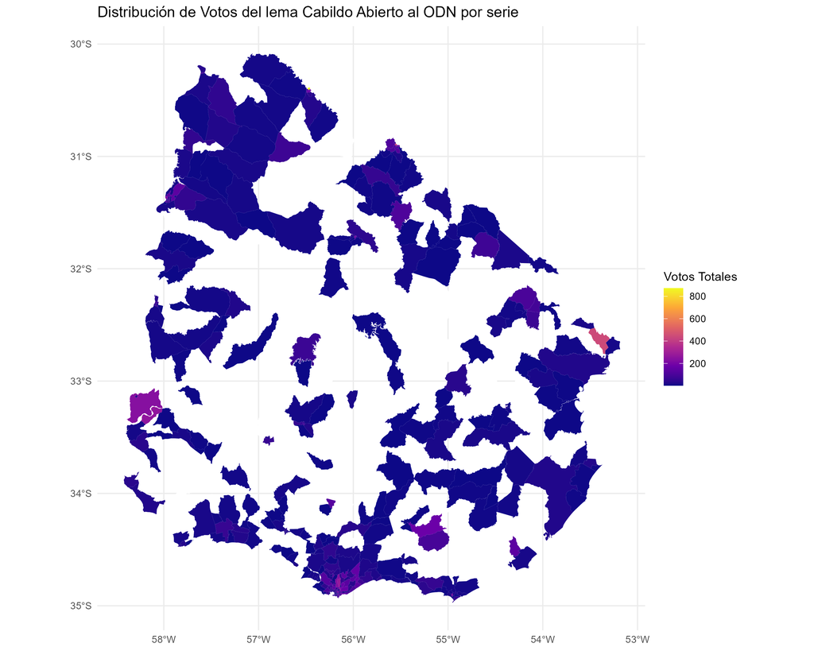

```r
library(scales)  # Necesario para pretty_breaks

# Calcular los quintiles
min_votos <- quantile(votos_por_serie_cabildo$votos_totales, 0.2, na.rm = TRUE)  # Percentil 20
max_votos <- max(votos_por_serie_cabildo$votos_totales, na.rm = TRUE)  # Valor máximo de votos

# Crear el mapa coroplético
mapa_coropletico_3 <- ggplot(votos_por_serie_cabildo) +
  geom_sf(aes(fill = votos_totales), color = NA) +
  scale_fill_viridis_c(option = "plasma", na.value = "white",
                       limits = c(min_votos, max_votos),  # Establece los límites en la escala de colores
                       breaks = pretty_breaks(n = 5)) +   # Crea cinco cortes de manera automática
  theme_minimal() +
  labs(title = "Distribución de Votos del lema Cabildo Abierto al ODN por serie",
       fill = "Votos Totales")

# Guardar el gráfico como archivo PNG
ggsave("mapa_coropletico_3.png", plot = mapa_coropletico_3, width = 10, height = 8, dpi = 300)
```

En este caso, el rango de colores (viridis - opción “plasma”) utiliza una paleta de colores “plasma” de la librería viridis, que pasa de tonos de púrpura y azul a tonos de amarillo:

Tonos más claros (amarillos) representan áreas con un mayor número de votos. Tonos más oscuros (púrpuras y azules) representan áreas con un menor número de votos. Áreas en blanco representan zonas con datos faltantes o donde los votos están por debajo del percentil 20 (tratando de limpiar visualmente las series con bajos registros de votos).

Con independencia del procedimiento de mapeo seleccionado, se evidencia que las zonas urbanas presentan la mayor presencia de votos de CA. Fundamentalmente, departamentos como Artigas, Cerro Largo, Rivera, Soriano, Río Negro, así como al NE de la capital.